```python
from bs4 import BeautifulSoup
import requests
import pandas as pd
import matplotlib.pyplot as plt
import numpy as np
import warnings
```

# Web Scraping

Initially we get the URL from the website, in this case Job Bank Canada. Later on we will make the request of the information and we will save it on a variable called response.

```python
url = "https://www.jobbank.gc.ca/jobsearch/jobsearch?d=50&fage=30&fcid=395&fcid=12562&fcid=12564&fcid=12565&mid=39070&term=bookkeeper&page=1&sort=D"
```

```python
response = requests.get(url)
```

## Check the response and convert it into and HTML code

> Here we can double check that the resquest was successful

```python
#Here we can double check that the resquest was successful
response
```

```
<Response [200]>
```

> Here we convert the text that we got from the request into and HTML code

```python
soup = BeautifulSoup(response.content, 'html.parser')
```

## Get the names of the Companies

```python
business1 = soup.find_all('li', attrs={'class': 'business'})
business1
```

```
[<li class="business">Heroistic Homes Ltd</li>,
 <li class="business">Magma Logistic Solutions Inc.</li>,
 <li class="business">MANDER BROS ENTERPRISES LTD.</li>,
 <li class="business">STOP'N GO ENTERPRISES INCORPORATED</li>,
 <li class="business">SG bros construction ltd</li>,
 <li class="business">Hi End Drywall Services Ltd</li>,
 <li class="business">Global Insurance Agency (2008) Ltd.</li>,
 <li class="business">ARVINDER MAAN PERSONAL REAL ESTATE CORPORATION</li>,
 <li class="business">UNIVER LOGISTICS INC.</li>,
 <li class="business">Applewood Kitchen Concepts Ltd.</li>,
 <li class="business">NORTHWEST TRUCK LINES INC.</li>,
 <li class="business">AQUATECH PLUMBING SUPPLIES LTD</li>,
 <li class="business">1155185 BC Ltd</li>,
 <li class="business">HOT PAN PIZZA LTD</li>,
 <li class="business">Freshslice Pizza</li>,
 <li class="business">Nexus Tech labs Inc.</li>,
 <li class="business">0923986 BC Ltd</li>,
 <li class="business">2020 Eye Care</li>,
 <li class="business">SRS Tax &amp; Accounting Services Inc</li>,
 <li class="business">AHC Express Ltd</li>,
 <li class="business">Galactic Transport Logistics Limited</li>,
 <li class="business">Langley Gymnastics Foundation</li>,
 <li class="business">F&amp;S Packaging Ltd</li>,
 <li class="business">Parihar &amp; Associates</li>,
 <li class="business">The Chopped Leaf</li>]
```

> We only need the names without the tags from the HTML code.

```python
text_list = []
for company in business1:
    text_list.append(company.get_text())

type(text_list)
text_list
```

```
['Heroistic Homes Ltd',
 'Magma Logistic Solutions Inc.',
 'MANDER BROS ENTERPRISES LTD.',
 "STOP'N GO ENTERPRISES INCORPORATED",
 'SG bros construction ltd',
 'Hi End Drywall Services Ltd',
 'Global Insurance Agency (2008) Ltd.',
 'ARVINDER MAAN PERSONAL REAL ESTATE CORPORATION',
 'UNIVER LOGISTICS INC.',
 'Applewood Kitchen Concepts Ltd.',
 'NORTHWEST TRUCK LINES INC.',
 'AQUATECH PLUMBING SUPPLIES LTD',
 '1155185 BC Ltd',
 'HOT PAN PIZZA LTD',
 'Freshslice Pizza',
 'Nexus Tech labs Inc.',
 '0923986 BC Ltd',
 '2020 Eye Care',
 'SRS Tax & Accounting Services Inc',
 'AHC Express Ltd',
 'Galactic Transport Logistics Limited',
 'Langley Gymnastics Foundation',
 'F&S Packaging Ltd',
 'Parihar & Associates',
 'The Chopped Leaf']
```

## Get the Location

> The location comes with a format that is not convinient in a table form. In this case we converted the list into a text string (textstring variable), so, later it can be cleaned properly with regular expressions.

```python
location = soup.find_all('li', attrs={'class': 'location'})

loc_list = []
for loc in location:
    loc_list.append(loc.get_text())

textstring = ''.join(loc_list)
type(textstring)

textstring
```

```
' Location\n\t\t\t\t\t\t\t\n\t\t\t\t\t\t\t\t\t\t\t\t   \t\tSurrey (BC)\n\t\t\t\t\t\t\t\t\t\t\t\t\t\n\t\t\t\t\t Location\n\t\t\t\t\t\t\t\n\t\t\t\t\t\t\t\t\t\t\t\t   \t\tSurrey (BC)\n\t\t\t\t\t\t\t\t\t\t\t\t\t\n\t\t\t\t\t Location\n\t\t\t\t\t\t\t\n\t\t\t\t\t\t\t\t\t\t\t\t   \t\tSurrey (BC)\n\t\t\t\t\t…
```

> Here we need to clean the new string and eliminate all the characters that will not be usefull at the end we will have a clean string.

```python
clean = textstring.replace('\t','').replace('\n','').replace('Location','').replace('    ','').replace('''''','')

clean
```

```
'Surrey (BC)Surrey (BC)Surrey (BC)Burnaby (BC)Surrey (BC)Surrey (BC)Surrey (BC)Surrey (BC)Surrey (BC)Surrey (BC)Surrey (BC)Vancouver (BC)White Rock (BC)Surrey (BC)Langley (BC)Burnaby (BC)Port Moody (BC)Surrey (BC)Surrey (BC)Surrey (BC)Surrey (BC)Langley (BC)Richmond (BC)Surrey (BC)Surrey (BC)'
```

> Now, with the clean string we can create a list with the wanted values

```python
location_final = clean.split("(BC)")

location_final = list(filter(lambda x: x.strip(), location_final))

location_final
```

```
['Surrey ',
 'Surrey ',
 'Surrey ',
 'Burnaby ',
 'Surrey ',
 'Surrey ',
 'Surrey ',
 'Surrey ',
 'Surrey ',
 'Surrey ',
 'Surrey ',
 'Vancouver ',
 'White Rock ',
 'Surrey ',
 'Langley ',
 'Burnaby ',
 'Port Moody ',
 'Surrey ',
 'Surrey ',
 'Surrey ',
 'Surrey ',
 'Langley ',
 'Richmond ',
 'Surrey ',
 'Surrey ']
```

## Get the salary

> Just as in the previous section we need to clean the list that we get as a result. The main goal is to get the value of the hourly wage.

```python
salary = soup.find_all('li', attrs={'class': 'salary'})
sal_list = []
for sal in salary:
    sal_list.append(sal.get_text())
textstring_sal = ''.join(sal_list)

sal_list
```

```
['\t\t   \t\t\t\n\t\t\t\t\t\t\t\tSalary:\n\t\t\t\t\t\t\t\t$27.00 hourly',
 '\t\t   \t\t\t\n\t\t\t\t\t\t\t\tSalary:\n\t\t\t\t\t\t\t\t$25.50 hourly',
 '\t\t   \t\t\t\n\t\t\t\t\t\t\t\tSalary:\n\t\t\t\t\t\t\t\t$25.00 hourly',
 '\t\t   \t\t\t\n\t\t\t\t\t\t\t\tSalary:\n\t\t\t\t\t\t\t\t$25.50 hourly',
 '\t\t   \t\t\t\n\t\t\t\t\t\t\t\tSalary:\n\t\t\t\t\t\t\t\t$27.00 hourly',
 '\t\t   \t\t\t\n\t\t\t\t\t\t\t\tSalary:\n\t\t\t\t\t\t\t\t$27.00 hourly',
 '\t\t   \t\t\t\n\t\t\t\t\t\t\t\tSalary:\n\t\t\t\t\t\t\t\t$26.50 hourly',
 '\t\t   \t\t\t\n\t\t\t\t\t\t\t\tSalary:\n\t\t\t\t\t\t\t\t$26.50 hourly',
 '\t\t   \t\t\t\n\t\t\t\t\t\t\t\tSalary:\n\t\t\t\t\t\t\t\t$25.00 hourly',
 '\t\t   \t\t\t\n\t\t\t\t\t\t\t\tSalary:\n\t\t\t\t\t\t\t\t$25.00 hourly',
 '\t\t   \t\t\t\n\t\t\t\t\t\t\t\tSalary:\n\t\t\t\t\t\t\t\t$28.00 hourly',
 '\t\t   \t\t\t\n\t\t\t\t\t\t\t\tSalary:\n\t\t\t\t\t\t\t\t$26.50 hourly',
 '\t\t   \t\t\t\n\t\t\t\t\t\t\t\tSalary:\n\t\t\t\t\t\t\t\t$25.00 hourly',
 '\t\t   \t\t\t\n\t\t\t\t\t\t\t\tSalary:\n\t\t\t\t\t\t\t\t$25.00 hourly',
 '\t\t   \t\t\t\n\t\t\t\t\t\t\t\tSalary:\n\t\t\t\t\t\t\t\t$28.00 hourly',
 '\t\t   \t\t\t\n\t\t\t\t\t\t\t\tSalary:\n\t\t\t\t\t\t\t\t$27.00 hourly',
 '\t\t   \t\t\t\n\t\t\t\t\t\t\t\tSalary:\n\t\t\t\t\t\t\t\t$19.00 hourly',
 '\t\t   \t\t\t\n\t\t\t\t\t\t\t\tSalary:\n\t\t\t\t\t\t\t\t$25.20 hourly',
 '\t\t   \t\t\t\n\t\t\t\t\t\t\t\tSalary:\n\t\t\t\t\t\t\t\t$27.00 hourly',
 '\t\t   \t\t\t\n\t\t\t\t\t\t\t\tSalary:\n\t\t\t\t\t\t\t\t$27.00 hourly',
 '\t\t   \t\t\t\n\t\t\t\t\t\t\t\tSalary:\n\t\t\t\t\t\t\t\t$26.95 hourly',
 '\t\t   \t\t\t\n\t\t\t\t\t\t\t\tSalary:\n\t\t\t\t\t\t\t\t$22.00 hourly',
 '\t\t   \t\t\t\n\t\t\t\t\t\t\t\tSalary:\n\t\t\t\t\t\t\t\t$24.00 to $28.00 hourly',
 '\t\t   \t\t\t\n\t\t\t\t\t\t\t\tSalary:\n\t\t\t\t\t\t\t\t$27.00 hourly',
 '\t\t   \t\t\t\n\t\t\t\t\t\t\t\tSalary:\n\t\t\t\t\t\t\t\t$28.00 hourly']
```

> Here we clean the string taking out all the values that we do not need

```python
clean_sal = textstring_sal.replace('\t','').replace('\n','').replace('Location','').replace('   ','').replace('','').replace('hourly','').replace('to','').replace('$','')

salary_final = clean_sal.split("Salary:")

salary_final = list(filter(lambda x: x.strip(), salary_final))

salary_final
```

```
['27.00 ',
 '25.50 ',
 '25.00 ',
 '25.50 ',
 '27.00 ',
 '27.00 ',
 '26.50 ',
 '26.50 ',
 '25.00 ',
 '25.00 ',
 '28.00 ',
 '26.50 ',
 '25.00 ',
 '25.00 ',
 '28.00 ',
 '27.00 ',
 '19.00 ',
 '25.20 ',
 '27.00 ',
 '27.00 ',
 '26.95 ',
 '22.00 ',
 '24.00  28.00 ',
 '27.00 ',
 '28.00 ']
```

> There is a value in the list with two rates, for the purpiose of this exercise we will take only the first one. Therefore, we will create a new list choosing only the first four digits of each element of the list

```python
salary_int = [str(num)[:4] for num in salary_final ]
salary_int
```

```
['27.0',
 '25.5',
 '25.0',
 '25.5',
 '27.0',
 '27.0',
 '26.5',
 '26.5',
 '25.0',
 '25.0',
 '28.0',
 '26.5',
 '25.0',
 '25.0',
 '28.0',
 '27.0',
 '19.0',
 '25.2',
 '27.0',
 '27.0',
 '26.9',
 '22.0',
 '24.0',
 '27.0',
 '28.0']
```

## Get the dates

> Once again we need to clean the list excluding the unwanted characters. In this case we convert the list into an string and make the cleaning starting from that point.

```python
date = soup.find_all('li', attrs={'class': 'date'})
date_list = []
for d in date:
    date_list.append(d.get_text())
textstring_date = ''.join(date_list)

textstring_date
```

```
'March 14, 2023\n\t\t\t\t\tMarch 14, 2023\n\t\t\t\t\tMarch 14, 2023\n\t\t\t\t\tMarch 14, 2023\n\t\t\t\t\tMarch 14, 2023\n\t\t\t\t\tMarch 14, 2023\n\t\t\t\t\tMarch 14, 2023\n\t\t\t\t\tMarch 14, 2023\n\t\t\t\t\tMarch 13, 2023\n\t\t\t\t\tMarch 13, 2023\n\t\t\t\t\tMarch 13, 2023\n\t\t\t\t\tMarch 13, 202…
```

> We clean the string and finally we convert the result into a list once again.

```python
clean_dat = textstring_date.replace('\t','').replace('\n','').replace('Location','').replace('   ','').replace('','')

clean_dat = clean_dat.split(", 2023")

clean_dat = list(filter(lambda x: x.strip(), clean_dat))

clean_dat
```

```
['March 14',
 'March 14',
 'March 14',
 'March 14',
 'March 14',
 'March 14',
 'March 14',
 'March 14',
 'March 13',
 'March 13',
 'March 13',
 'March 13',
 'March 13',
 'March 13',
 'March 13',
 'March 13',
 'March 13',
 'March 13',
 'March 13',
 'March 13',
 'March 13',
 'March 13',
 'March 13',
 'March 12',
 'March 12']
```

# Create a dictionary of list

```python
# Create a dictionary of lists

data = {'Company': text_list, 'Location': location_final, 'Salary': salary_int, 'Date': clean_dat}
```

> Create the Data Frame using the dictionary list

```python
df = pd.DataFrame(data)
print(df)
```

```
                                           Company     Location Salary  \
0                              Heroistic Homes Ltd      Surrey    27.0
1                    Magma Logistic Solutions Inc.      Surrey    25.5
2                     MANDER BROS ENTERPRISES LTD.      Surrey    25.0
3               STOP'N GO ENTERPRISES INCORPORATED     Burnaby    25.5
4                         SG bros construction ltd      Surrey    27.0
5                      Hi End Drywall Services Ltd      Surrey    27.0
6              Global Insurance Agency (2008) Ltd.      Surrey    26.5
7   ARVINDER MAAN PERSONAL REAL ESTATE CORPORATION      Surrey    26.5
8                            UNIVER LOGISTICS INC.      Surrey    25.0
9                  Applewood Kitchen Concepts Ltd.      Surrey    25.0
10                      NORTHWEST TRUCK LINES INC.      Surrey    28.0
11                  AQUATECH PLUMBING SUPPLIES LTD   Vancouver    26.5
12                                  1155185 BC Ltd  White Rock    25.0
13                               HOT PAN PIZZA LTD      Surrey    25.0
```

[output cut: 38 more lines]

# Graphs

### Demand by Location

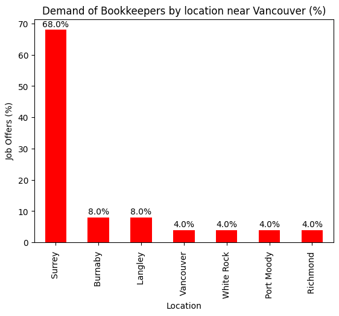

```python
# Count the frequency of a job offer depending on the location.

counts = df['Location'].value_counts()

# Calculate the percentage of each location

percentages = counts / counts.sum() * 100

# Create a bar chart

ax = percentages.plot(kind='bar', color='red')

# Add labels and title

plt.xlabel('Location')
plt.ylabel('Job Offers (%)')
plt.title('Demand of Bookkeepers by location near Vancouver (%)')

# Add the percentage values to the bars

for i, v in enumerate(percentages):
    ax.text(i, v + 1, f'{v:.1f}%', ha='center')

# Show the chart

plt.show()
```

### Salary range by Location

```python
# Convert the salary column to an integer
df['Salary'] = pd.to_numeric(df['Salary'])
print(df.dtypes)
```

```
Company      object
Location     object
Salary      float64
Date         object
dtype: object
```

> Now with salary as numerical data we can create a box plot of the salary based on the Location.

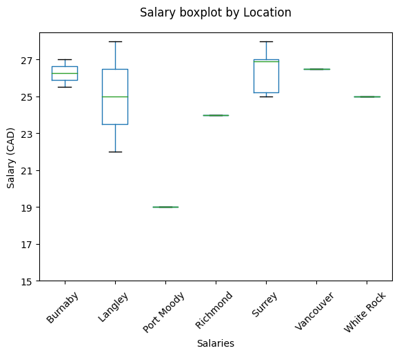

```python
# Create the figure

fig, ax = plt.subplots()
df.boxplot(column='Salary', by='Location', ax=ax)

# Remove the Grid
ax.grid(False)

# Y axis two dollar unit change
ax.set_yticks(range(15, int(df['Salary'].max())+1, 2))

# Add labels and title
plt.xlabel('Salaries')
plt.ylabel('Salary (CAD)')

# Rotate the labels in the X axis 45 degrees

plt.xticks(rotation=45)

# Title

plt.suptitle('Salary boxplot by Location')
ax.set_title('')



# Show the chart
plt.show()
```

# Create one figure with both plots

> Now the idea is to consolidate in one figure both plots (bar chart and box chart). We will take the previous lines of code to create the figure

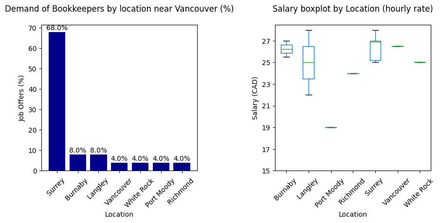

```python
# To ignore the user warning message
warnings.filterwarnings("ignore", category=UserWarning)

# Count the frequency of a job offer depending on the location.
counts = df['Location'].value_counts()

# Calculate the percentage of each location
percentages = counts / counts.sum() * 100

# Create the figure
fig, (ax1, ax2) = plt.subplots(nrows=1, ncols=2, figsize=(10, 4))

# Create a bar chart
ax1.bar(percentages.index, percentages.values, color='darkblue')
ax1.set_xlabel('Location')
ax1.set_ylabel('Job Offers (%)')
for i, v in enumerate(percentages):
    ax1.text(i, v + 1, f'{v:.1f}%', ha='center')
ax1.set_title('Demand of Bookkeepers by location near Vancouver (%)', pad=20)
ax1.set_xticklabels(percentages.index, rotation=45)


# Create a boxplot
df.boxplot(column='Salary', by='Location', ax=ax2)
ax2.grid(False)
ax2.set_yticks(range(15, int(df['Salary'].max())+1, 2))
ax2.set_xlabel('Location')
ax2.set_ylabel('Salary (CAD)')
ax2.set_xticklabels(ax2.get_xticklabels(), rotation=45)
ax2.set_ylabel('Salary (CAD)')
ax2.set_title('Salary boxplot by Location (hourly rate)', pad=20)

# Add spacing between the subplots
plt.subplots_adjust(wspace=0.5)

#Title of the entire figure
fig.suptitle('')

# Show the figure
plt.show()
```